# Introduction

Cryptography has been around for centuries and is simply a form of communication. The most simple definition of cryptography is the art of creating and interpreting secret messages. To create a secret message is called “encrypting” and to interpret a secret message is called “decrypting.”

# Ancient History of Cryptography

## Caesar’s Cipher

One of the oldest and most famous methods of cryptography is known as the Caesar’s Cipher used in the first century B.C. by Julius Caesar[@leftonNumberTheoryPublicKey1991]. The Caesar’s Cipher is quite simple and is known as a substitution cipher. It is just a shifting of the alphabet. First, assign the numbers 0-25 to the alphabet respectively. Then, the encrypter will choose a shift. Suppose the shift is $n = 2$. Each letter in the alphabet will shift 2 units to the right. A will become 2, B will become 3, C will become 4, and so on. Using modular arithmetic, this can be explained using $E_n(x) = x+n(mod 26)$ where $x$ is the numerical value of the letter and $n$ is the shift value.

After encrypting the message and sending it, decrypting it is just as simple. All the receiver needs is the key to unlocking the message, the shifting value, $n$. To decrpyt, you simply use the function $D_n(x) = x - n (mod26)$.

Suppose I want to encrpyt the word “CRYPTOGRAPHY” to send to a fellow classmate using a shift of $n = 5$. First, I plug the numerical number value of each individual character in the string “CRYPTOGRAPHY” into the encrypting equation, $E_n(x) = n + x (mod26)$.

Caesar’s Cipher 5 Unit Shift

|  | 0 | 1 | 2 | 3 | 4 | 5 | 6 | 7 | 8 | 9 | 10 | 11 | 12 | 13 | 14 | 15 | 16 | 17 | 18 | 19 | 20 | 21 | 22 | 23 | 24 | 25 |
| --- | --- | --- | --- | --- | --- | --- | --- | --- | --- | --- | --- | --- | --- | --- | --- | --- | --- | --- | --- | --- | --- | --- | --- | --- | --- | --- |
| Alphabet | A | B | C | D | E | F | G | H | I | J | K | L | M | N | O | P | Q | R | S | T | U | V | W | X | Y | Z |
| Caesar | V | W | X | Y | Z | A | B | C | D | E | F | G | H | I | J | K | L | M | N | O | P | Q | R | S | T | U |

Now, the encrypted message will read the character string of “HWDUYTLWFUMD.” To decrypt, the fellow classmate will use the key of $n = 5$ along with the decrypting function $D_n(x)= x-n(mod26)$ to reverse the shift and read “CRYPTOGRAPHY.” However, if the message is intercepted, cracking the encrypted message would take no time at all even without the key. There are only 26 possible combinations of what the shift could be. Over time, this process of creating trickier encryption methods has become much more complex, yet the Caesar’s Cipher is still a foundational model of how cryptography works.

## Spartan Scytale

The Spartan Scytale is a type of transposition cipher dating back to fifth century B.C. used by the ancient Greeks in times of war.[@singhCodeBookScience2011] A permutation cipher is one in which the ordering of the message is changed by a certain rule. The spartan scytale was created using a wooden shaft with a thin strip of leather wrapped around it. The sender would then write his message down onto the leather. Once he unwrapped the leather with the new message on it, the message would become encrypted. Once received, the receiver would then wrap the strip of leather around a wooden shaft of the same width to decrypt the message.

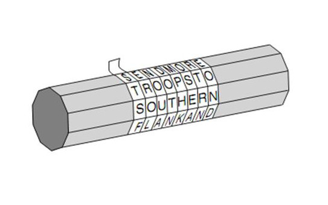

Spartan Scytale[2]

# Contemporary Cryptography

## Asymetric public-private Keys

Since the origination of secret messages, the challenge was for the sender and receiver of the message to have the same key for encoding and decoding a message. According to Auguste Kerckhoffs, one of the main principles of cryptography is the security of a cryptosystem should rely on the secrecy of a small parameter, the secret key.[@leftonNumberTheoryPublicKey1991] The process of “key distribution” required the delivery of the key to the receiver of the message. If the receiver did not have the key value for the Caesar’s Cipher, they could not read what it said. In modern times, all countries rely heavily on the security of information via cryptography. If one can find your key, they can read your information. As trade between countries increased post World War II, it required payments to be made across borders and sometimes at great distances. The cost associated with the delivery of keys became prohibitive and banks, in particular, began to investigate how to make the process more efficient. The solution that had evaded discovery for centuries was first proposed by two Americans: Whitfield Diffie and Martin Hellman in 1976. Their idea was to have an “asymmetric public-private key.” This discovery is considered “to be the greatest cryptographic achievement since the invention of the monoalphabetic cipher”[@singhCodeBook1999], just like Caesar’s Cipher, over two thousand years ago.”

## Diffie-Hellman

Whitfield Diffie was born in 1944 and graduated from the Massachusetts Institute of Technology in 1965. He then took a series of jobs in computer-security roles. Diffie recognized that the key distribution problem was a riddle for the ages. Diffie considered the situation where two people on the internet need to keep a message (e.g. e-mail) or a transaction private. The two parties need to share a key, but exchanging the key securely became a problem. The volume of messages and transactions made the physical delivery of the key impractical. Without secure encryption, communication would be impossible because messages and credit card information could be discovered.

At a talk at IBM, Diffie learned that a Stanford University professor was also interested in the problem, Martin Hellman. In 1974, he received a call from Whitfield Diffie and agreed to a half-hour meeting at his office. The half-hour meeting turned into hours with Diffie leaving Hellman’s home at midnight. The two formed a partnership with another cryptography fanatic, Professor Ralph Merkle, to address the key distribution problem.

## A Simple Example

Examples from cryptography involve a traditional cast of characters: Alice, Bob, and Eve. Alice (A) and Bob (B) wish to exchange a secure message Eve wishes to eavesdrop and steal the message. Before Diffie-Hellman, Alice and Bob would have to meet to exchange keys. If they were exchanging lots of messages or wanted to change encryption methods, they might have to meet weekly. The system breaks down when one of them gets sick. Couriers could help but they also add complexity and potential insecurity to the process.

Let’s envision a situation where Alice puts her message in a box and then padlocks it with a key. Alice keeps the key. When Bob receives the message, he has no way to open the padlock. Bob needs the key that Alice retained. This is essentially the age-old problem but restated. Diffie-Hellman changed the way the problem was conceived. Instead, they described this situation. Alice locks the message in a box with her lock, retaining the key, and sends the box to Bob. Bob then takes the box, adds his lock with his key, and returns the box to Alice. Alice receives the box but it now has two locks. She takes her lock off the box, leaving only Bob’s lock. She then sends the box back to Bob and Bob receives the box with only his lock. He removes the lock with the key he retained and can finally read the message. No padlock key was exchanged.

Diffie-Hellman’s contribution was to propose a theoretical method whereby an encrypted message could be exchanged without the need for exchanging the keys. The use of keys is asymmetric in that Alice’s padlock key (the key that encrypted the message) is different from Bob’s padlock key (the key that decrypted the message). The discovery was “revolutionary.” Their research left unresolved how the encryption was to occur. They needed a mathematical function that was easy to encrypt but impossible for an eavesdropper to decipher.

## Trapdoor Encryption

To turn the concept of asymmetric ciphers into a practical invention, a mathematician needed to create a function that acted as a lock. Some mathematical functions are considered to be two-way functions in that they are easy to do and undo. They act like a light switch where the effort to turn the switch on is the same as turning it off. For example, doubling a number takes the same effort as dividing a number by two. Diffe and Hellman were not interested in two-way functions, but instead, were looking for a one-way or “trapdoor” function. A trapdoor function is one where it was possible to apply a function to a number but much harder to reverse. These kinds of functions are sometimes described as “Humpty-Dumpty” functions because it’s easy to get Humpty-Dumpty up on the wall, but hard to put him back together after he falls. Diffe-Hellman-Merkle would attempt to find a solution in modular arithmetic, but the one-way mathematical encryption would ultimately be solved by another group of mathematicians.

A workable trapdoor mathematical function would be discovered by Ron Rivest, Adi Shamir, and Leonard Adleman. (The initials of their surnames form the acronym “RSA”.) The three researchers worked together at an MIT Laboratory for Computer Science and applied different approaches to the problem for a year. One evening after some Manischewitz wine, Rivest stumbled upon a possible approach and wrote the equivalent of a scientific paper overnight. He showed the solution to his partners and, after a friendly dispute on the order of authors, they submitted the paper. Adelman thought at the time that the paper would be “the least interesting paper” that he ever authored. The system “went on to become the most influential cipher in modern cryptography.” [@singhCodeBookScience2011]

RSA was first announced in August 1977 in *Scientific American*. The article, “A New Kind of Cipher that Would Take Millions of Years to Break,” was authored by Martin Gardner. Gardner issued a challenge to the public to decode a message and issued the public key. The message was decoded seventeen years later and required six hundred volunteers.

## Dual Discoveries

Asymmetric public key encryption was discovered earlier in Great Britain by James Ellis who worked for the Government Communications Headquarters, but knowledge of the discovery was delayed because of national security. Ellis was a pack rat of academic articles and discovered the idea in a trove of old telecommunications articles. A paper proposed the idea of adding noise to the telephone line to make the signal unintelligible. The recipient would then remove the noise to hear the message. Lacking the mathematical background to create a padlock, Ellis’ discovery languished until a new mathematician joined the team. Clifford Cocks, a recent graduate of Cambridge with a specialization in number theory, discovered a one-way function. In recalling his epiphany, he said “it was natural to think about one-way functions, something you could do but not undo. Prime numbers and factoring was a natural candidate.” From start to finish, Cocks estimated that it took him no more than half an hour to solve. [@singhCodeBook1999]

# The RSA Algorithm

Cryptography has become more important as we communicate globally with the internet. The sharing of credit card numbers, social security numbers, names, etc. online is an everyday occurrence and security for our information is a must. RSA cryptography is one solution protecting us from those who wish to steal our information. The RSA algorithm can be broken up into 3 sections: key generation, encryption, and decryption.

Step 1: Find two large primes, $p_0$ and $p_1$, such that their product, $n$, is of the required bit length. The length of $n$ will usually be of the standard 1024, 2048, or 3027 bits.[@NationalInstituteStandards]

Step 2: Calculate $n= p_0\cdot p_1$ and use Euler’s Totient Function to calculate $\phi(n) = (p_0-1)\cdot (p_1-1)$.

Step 3: Choose some integer $e$ such that $(e,\phi(n)) = 1$ where $1<e<\phi(n)$.

Step 4: Calculate $d$, the multiplicative inverse of $e(mod\:\phi(n))$. i.e. $d\equiv e^{-1} (mod\:\phi(n))$

Step 5: Key generation is finished. The “public key” is now $(n, e)$ and the “private key” is $(n, d)$.

Step 6: Encrypt the message using $C\equiv M^e(mod\:n)$ to calculate the least residue $(mod\:n)$. $C$ stands for the ciphertext and $M$ stands for the original message.

Step 7: Decrypt the ciphertext using $M\equiv C^d(mod\:n)$ to calculate the least residue $(mod\:n)$.